# Main steps

2016-09-21

## Objective

The vignette demonstrates the main functions in the `brokenstick` package: `brokenstick()`, `predict()` and `export`.

## Data set

The `smocc_hgtwgt` data in the `brokenstick` package contain the heights and weights of 1933 Dutch children measured on 10 visits at ages 0-2 years. Here we take the first 2000 records from the data.

```r
require("brokenstick")
smc <- smocc_hgtwgt[1:2000, ]
head(smc)
```

```
##     src subjid rec nrec    age agedays    sex etn gagebrth birthwt htcm
## 1 smocc  10001   1   10 0.0000       0 Female  NL      283    3960 52.0
## 2 smocc  10001   2   10 0.0821      30 Female  NL      283    3960 55.6
## 3 smocc  10001   3   10 0.1588      58 Female  NL      283    3960 58.2
## 4 smocc  10001   4   10 0.2546      93 Female  NL      283    3960 61.2
## 5 smocc  10001   5   10 0.5038     184 Female  NL      283    3960 67.2
## 6 smocc  10001   6   10 0.7529     275 Female  NL      283    3960 70.2
##     haz wtkg    waz
## 1 1.531 3.96  1.490
## 2 1.007 4.05 -0.215
## 3 0.700 4.56 -0.779
## 4 0.598 5.09 -1.143
## 5 0.615 6.81 -0.586
## 6 0.004 7.77 -0.478
```

Another way to obtain the same data is to use the `get_smocc_data()` function from the `github::HBGDki/hbgd` package, followed by a little post-processing:

```r
if (!require(hbgd)) devtools::install_github("HBGDki/hbgd")
smc2 <- hbgd::get_smocc_data()[1:2000, ]
smc2$subjid <- as.numeric(as.character(smc2$subjid))
smc2$src <- as.character(smc2$src)
smc2$agedays <- round(smc2$agedays)
smc2$age <- round(smc2$agedays / 365.25, 4)
smc2$gagebrth <- smc2$ga * 7 + 3
smc2$etn <- as.character(smc2$etn)
smc2$birthwt <- smc2$bw
smc2$haz <- round(who_htcm2zscore(smc2$agedays, smc2$htcm, smc2$sex), 3)
smc2$waz <- round(who_wtkg2zscore(smc2$agedays, smc2$wtkg, smc2$sex), 3)
keep <- c("src", "subjid", "rec", "nrec",
          "age", "agedays", "sex", "etn",
          "gagebrth", "birthwt",
          "htcm", "haz", "wtkg", "waz")
smc2 <- smc2[, keep]
identical(smc, smc2)
```

```
## [1] TRUE
```

Variable names and types conform to the definition in `hbgd::view_variables()`.

## Exporatory analysis

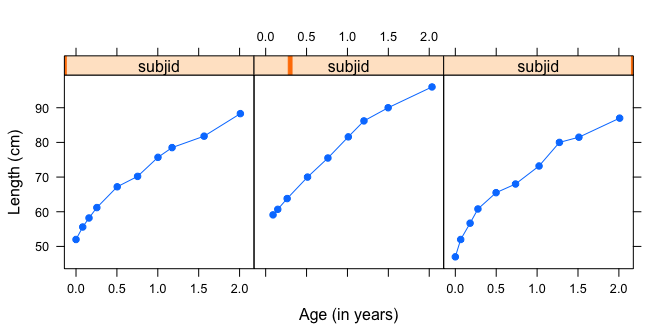

```r
ids <- c(10001, 10005, 10022)
require("lattice")
xyplot(htcm ~ age | subjid, data = smc,
       subset = subjid %in% ids,
       type = "b", pch = 19, as.table = TRUE,
       xlab = "Age (in years)", ylab = "Length (cm)")
```

The plots gain more resolution when the Standard Deviation Scores (SDS) (or $Z$-values) are plotted. The column `haz` contains the $Z$-scores of height relative to the WHO standard.

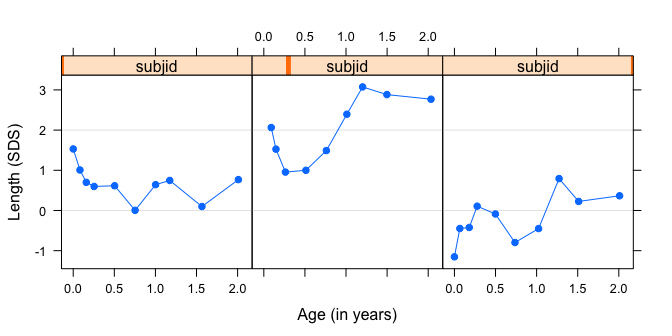

```r
xyplot(haz ~ age | subjid, data = smc,
       subset = subjid %in% ids,
       type = "b", pch = 19, as.table = TRUE,
       panel = function(...) {
        panel.refline(h = c(-2, 0, 2))
        panel.xyplot(...)
       },
       xlab = "Age (in years)", ylab = "Length (SDS)")
```

### Broken stick model with two lines

The *broken stick model* describes a trajectory by a series of connected straight lines. We first calculate a rough approximation in the above trajectory using only use two lines. The first line should start at birth and end at the age of exactly 1 years, while the second spans the period from 1 to 2 years. In addition, the lines connect at the age of 1 year.

```r
knots <- 0:2
fit1 <- brokenstick(y = smc$haz,
                    x = smc$age,
                    subject = smc$subjid,
                    knots = knots)
```

The `knots` argument to `brokenstick()` specifies that the break ages are birth, 1 year and 2 years, respectively. In total, there are four knots:

```r
get_knots(fit1)
```

```
## [1] 0.0000 1.0000 2.0000 2.6776
```

This broken stick model uses break ages 0, 1 and 2 years. The knot at age 2.6776 is equal to the maximum age, and is added automatically for technical reasons since the knot range must at least be a wide as the age range in the data. The first and last knots may also be specified manually by the boundary argument, e.g. `boundary = c(0, 3)`.

```r
class(fit1)
```

```
## [1] "brokenstick"
```

```r
fit1
```

```
## Linear mixed model fit by REML ['brokenstick']
## Formula: y ~ 0 + x1 + x2 + x3 + x4 + (0 + x1 + x2 + x3 + x4 | subject)
##    Data: data
## REML criterion at convergence: 4029.238
## Random effects:
##  Groups   Name Std.Dev. Corr
##  subject  x1   1.1765
##           x2   0.9587    0.50
##           x3   0.9021    0.51  0.98
##           x4   0.6710   -0.09  0.42  0.58
##  Residual      0.5042
## Number of obs: 1960, groups:  subject, 206
## Fixed Effects:
##     x1      x2      x3      x4
## 0.1117  0.3499  0.5120  0.7555
```

The `brokenstick()` function calls the `lmer()` function for model fitting. The `fit1` object is of S4 class `brokenstick`, which contains the results of `lmer()` as well as some additional slots related to the knot specification.

The column labeled `Std.Dev.` contains the standard deviations of the random effects. These numbers are expected to be around 1, since - under the assumption that the WHO standard appropriately describes this sample - the dependent variable follow a standard normal distribution with zero mean and standard deviation equal to one. The `Corr` component of the random effects lists the correlations between the broken stick estimates between the time point. Thus, the correlation between the estimates at birth (`x1`) and at 2 years (`x3`) is 0.51. The standard deviation of the residuals (within-person error) for this model is of 0.50.

## Predicted values

The broken stick model defines predicted values as a compromise between the person’s data values and the global mean. This compromise is called the *conditional mean* of the posterior distribution, it is calculated as the sum of fixed and random effects. The `predict()` function obtains predictions from the broken stick model. In order to obtain the predicted values for each measured data point for all children in the fitted model use

```r
p1 <- predict(fit1)
dim(p1)
```

```
## [1] 1960    5
```

```r
head(p1, 4)
```

```
##   subjid      x     y      yhat  knot
## 1  10001 0.0000 1.531 0.9588267 FALSE
## 2  10001 0.0821 1.007 0.9118383 FALSE
## 3  10001 0.1588 0.700 0.8679405 FALSE
## 4  10001 0.2546 0.598 0.8131112 FALSE
```

The observed $Z$-score is stored in column called `y`, and the corresponding broken stick estimates are stored in the column called `yhat`. The column `knot` is set to `FALSE` if `y` is actually observed. We obtain the connected lines according to the broken stick model by obtaining predictions at the break ages by specifying the `at = "knots"` argument.

```r
p2 <- predict(fit1, at = "knots")
head(p2, 4)
```

```
##   subjid      x  y      yhat knot
## 1  10001 0.0000 NA 0.9588267 TRUE
## 2  10001 1.0000 NA 0.3864955 TRUE
## 3  10001 2.0000 NA 0.5703590 TRUE
## 4  10001 2.6776 NA 0.5948198 TRUE
```

Break ages are distinguihsed from observed ages by the `knot` column, which is now `TRUE`. We may obtain both types of estimates simultaneously for all children by

```r
p <- predict(fit1, x = get_knots(fit1))
head(p, 15)
```

```
##      subjid      x     y       yhat  knot
## 1     10001 0.0000 1.531  0.9588267 FALSE
## 1961  10001 0.0000    NA  0.9588267  TRUE
## 2     10001 0.0821 1.007  0.9118383 FALSE
## 3     10001 0.1588 0.700  0.8679405 FALSE
## 4     10001 0.2546 0.598  0.8131112 FALSE
## 5     10001 0.5038 0.615  0.6704862 FALSE
## 6     10001 0.7529 0.004  0.5279185 FALSE
## 2100  10001 1.0000    NA  0.3864955  TRUE
## 7     10001 1.0021 0.642  0.3868816 FALSE
## 8     10001 1.1745 0.747  0.4185796 FALSE
## 9     10001 1.5661 0.098  0.4905806 FALSE
## 3100  10001 2.0000    NA  0.5703590  TRUE
## 10    10001 2.0096 0.768  0.5707056 FALSE
## 4100  10001 2.6776    NA  0.5948198  TRUE
## 11    10002 0.0000 0.589 -0.1348367 FALSE
```

We plot the original data and the broken stick estimates jointly by `xyplot()` from the `lattice` package by

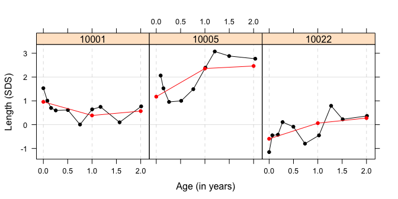

```r
p$yhat[!p$knot] <- NA
xyplot(y + yhat ~ x | subjid, data = p,
       subset = subjid %in% ids & x <= 2.3,
       as.table = TRUE,
       panel = function(...) {
         panel.refline(h = c(-2, 0, 2))
         panel.refline(v = 0:2, col = "grey", lwd = 0.5, lty = 2)
         panel.superpose(...)},
       panel.groups = function(x, y, subscripts, groups, ..., group.number)
         with(na.omit(data.frame(x, y)),
              panel.lines(x, y, type = "b", pch = 20, col = group.number)),
       xlab = "Age (in years)", ylab = "Length (SDS)")
```

## Extension to nine lines

We now refine the model in the first two years by adding a knot for each age at which a visit was scheduled. This model can be run as

```r
# 10 scheduled visits
knots <- round(c(0, 1, 2, 3, 6, 9, 12, 15, 18, 24)/12, 4)
boundary <- c(0, 3)
fit2 <- brokenstick(y = smc$haz,
                    x = smc$age,
                    subject = smc$subjid,
                    knots = knots,
                    boundary = boundary)
```

```
## Warning: number of observations (=1960) <= number of random effects (=2266)
## for term (0 + x1 + x2 + x3 + x4 + x5 + x6 + x7 + x8 + x9 + x10 + x11 |
## subject); the random-effects parameters and the residual variance (or scale
## parameter) are probably unidentifiable
```

```
## Warning in commonArgs(par, fn, control, environment()): maxfun < 10 *
## length(par)^2 is not recommended.
```

```
## Warning in optwrap(optimizer, devfun, getStart(start, rho$lower, rho$pp), :
## convergence code 1 from bobyqa: bobyqa -- maximum number of function
## evaluations exceeded
```

```
## Warning in checkConv(attr(opt, "derivs"), opt$par, ctrl = control
## $checkConv, : Model failed to converge with max|grad| = 0.190157 (tol =
## 0.002, component 1)
```

The model contains 11 random effect, which represents a somewhat difficult estimation problem. The optimization routine issues a number of warnings related to the number of random effects relative to the number of observations, and the complexity of the optimization problem. These warnings may indicate degeneracies in the numerical solution, but are generally be less frequent for large samples.

As before, predicted values can be obtained by

```r
p <- predict(fit2, x = get_knots(fit_hgt))
head(p, 4)
```

```
##       subjid      x     y      yhat  knot
## 1      10001 0.0000 1.531 1.5234259 FALSE
## 11000  10001 0.0000    NA 1.5234259  TRUE
## 2      10001 0.0821 1.007 0.9882855 FALSE
## 2267   10001 0.0833    NA 0.9804637  TRUE
```

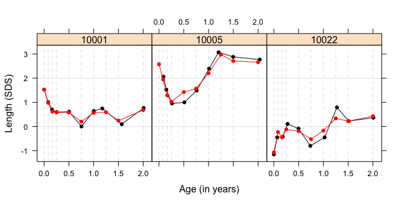

The figure plots the nine line model, with break points at the scheduled ages (indicated by the grey dashed lines). The model now fits the data very well. Formal model assessment can be done with standard `lmer` diagnostic plots. See the vignette on *Model diagnostics* for more detail [NOTE: vignette still has to be written].

The broken stick model is sensitive to the location of the knots. Some advice about knot placement: Evidently, using more knots can improve the fit to the data. However, adding an excessive number of knots will substantially increase calculation time, and create solutions that are less stable. Try using not more than the (average) number of data points per person. Also, knot placement requires some care. Here, the knots are added at the scheduled visits, which is a reasonable strategy for obtaining good predictions as there are generally many observations in the neighourbood of the scheduled ages. In contrast, placing knots at ages where the data are very sparse (e.g. exactly in-between visits) may result in bad predictions and should be avoided.

## Explained variance

The proportion of the variance of the outcome explained by the two-line model is

```r
var(fitted(fit1), na.rm = TRUE) / var(smc$haz, na.rm = TRUE)
```

```
## [1] 0.747355
```

For the second model we get

```r
var(fitted(fit2), na.rm = TRUE) / var(smc$haz, na.rm = TRUE)
```

```
## [1] 0.911458
```

so the nine-line broken stick model explains about 91 percent of the variance of the height SDS.

## Publishing your model

The `fit2` object can be stored by `save()` for future use in R. However, a more parsimonious and convenient way to reuse the model is to export its parameter estimates, and store only these. As a matter of fact, prediction using the broken stick model requires only the knot locations, the fixed effect estimates, the variance/covariance matrix of the random effects, and the size of the residual variance. The `export()` function will collect this information from the fitted model, and store it as a list.

```r
# export the broken stick models
export_hgt <- export(fit2)
attributes(export_hgt)
```

```
## $names
## [1] "beta"     "omega"    "sigma2"   "knots"    "boundary" "degree"
##
## $class
## [1] "brokenstick_export"
```

```r
lapply(export_hgt, round, 2)
```

```
## $beta
##    x1    x2    x3    x4    x5    x6    x7    x8    x9   x10   x11
##  0.64  0.02 -0.17 -0.04  0.31  0.34  0.39  0.44  0.33  0.57  0.56
##
## $omega
##       x1   x2   x3   x4   x5   x6   x7   x8   x9  x10  x11
## x1  1.87 1.25 1.22 1.10 0.70 0.68 0.55 0.50 0.48 0.42 0.61
## x2  1.25 1.41 1.25 1.17 0.91 0.74 0.66 0.64 0.63 0.52 0.92
## x3  1.22 1.25 1.37 1.17 0.90 0.74 0.61 0.59 0.64 0.52 0.51
## x4  1.10 1.17 1.17 1.23 0.93 0.82 0.67 0.66 0.66 0.59 0.37
## x5  0.70 0.91 0.90 0.93 1.01 0.91 0.86 0.80 0.82 0.72 0.13
## x6  0.68 0.74 0.74 0.82 0.91 0.98 0.85 0.84 0.84 0.75 0.34
## x7  0.55 0.66 0.61 0.67 0.86 0.85 0.89 0.88 0.85 0.78 0.31
## x8  0.50 0.64 0.59 0.66 0.80 0.84 0.88 0.96 0.92 0.86 0.78
## x9  0.48 0.63 0.64 0.66 0.82 0.84 0.85 0.92 0.98 0.87 0.64
## x10 0.42 0.52 0.52 0.59 0.72 0.75 0.78 0.86 0.87 0.94 0.54
## x11 0.61 0.92 0.51 0.37 0.13 0.34 0.31 0.78 0.64 0.54 4.29
##
## $sigma2
## [1] 0.07
##
## $knots
##  [1] 0.00 0.08 0.17 0.25 0.50 0.75 1.00 1.25 1.50 2.00
##
## $boundary
## [1] 0 3
##
## $degree
## [1] 1
```

Such estimates can be published as a longitudinal growth reference.

## Prediction using a published broken stick reference

```r
# four height measurement on new child
x <- c(0, 0.12, 0.32, 0.62, 1.1)
y <- c(-1.2, -1.8, -1.7, -1.9, -2.1)

# prediction at ages x
atx <- predict(export_hgt, y = y, x = x)
atx
```

```
##   subjid    x    y      yhat  knot
## 1     NA 0.00 -1.2 -1.167525 FALSE
## 2     NA 0.12 -1.8 -1.788304 FALSE
## 3     NA 0.32 -1.7 -1.770145 FALSE
## 4     NA 0.62 -1.9 -1.863223 FALSE
## 5     NA 1.10 -2.1 -1.930374 FALSE
```

```r
# prediction at the knots
atknots <- predict(export_hgt, y = y, x = x, at = "knots")
head(atknots)
```

```
##   subjid      x  y      yhat knot
## 1     NA 0.0000 NA -1.167525 TRUE
## 2     NA 0.0833 NA -1.768714 TRUE
## 3     NA 0.1667 NA -1.813232 TRUE
## 4     NA 0.2500 NA -1.745828 TRUE
## 5     NA 0.5000 NA -1.832674 TRUE
## 6     NA 0.7500 NA -1.896317 TRUE
```

The predicted values are found such that the published model fits best to the given age and height values. The figure below plots the observed data and the predicted data at the break ages for the new child.

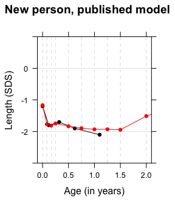